# Análisis evolución Covid-19 - Chile vs Italia, España, Brasil, Corea del Sur (29/03/2020)

Claudio Bustos

29/3/2020

**NOTA**: Lo que presento aquí es un ejemplo de como realizar análisis de series de tiempo, usando datos de la evolución total de casos disponible en fuentes públicas en internet. No tiene ninguna validez epidemiológica, ya que eso requería un modelo de la diseminación de la enfermedad. En particular, las predicciones son solo válidas en cuanto no existan cambios en las políticas públicas; si los hay, se esperaría que (ojalá) las predicciones fuesen incorrectas.

- Reportes anteriores: https://github.com/clbustos/analisis_covid19_chile

Comentario personal: Mañana tengo que entregar un informe gigante, así que solo pondré los gráficos. Mañana volvemos en regla.

## Análisis de datos observados

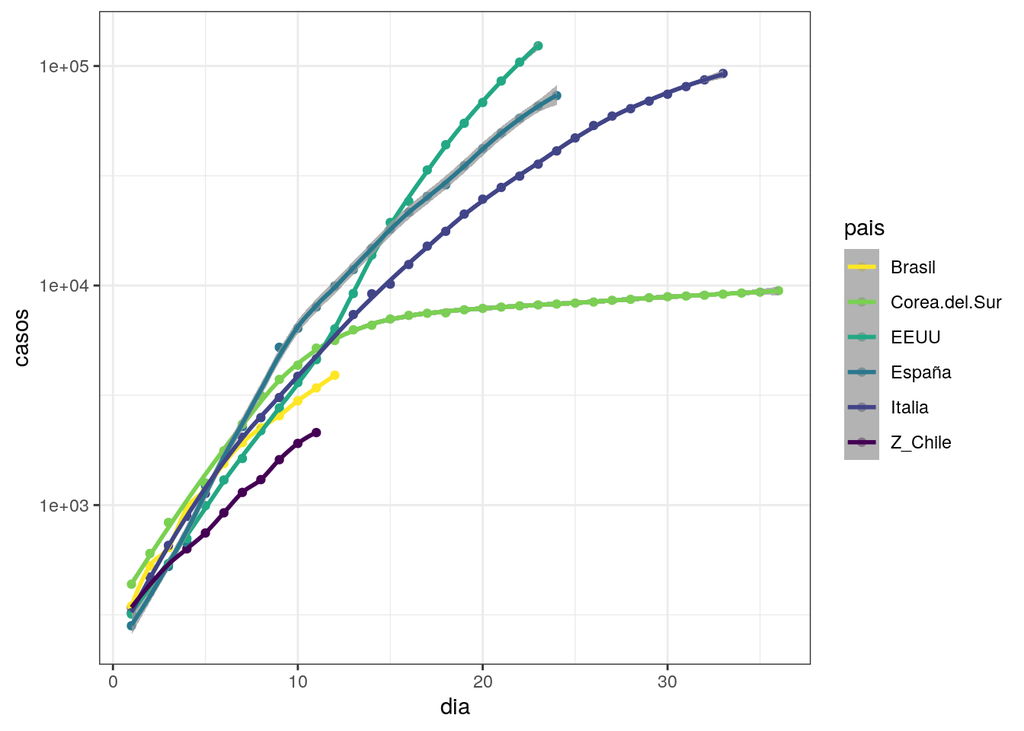

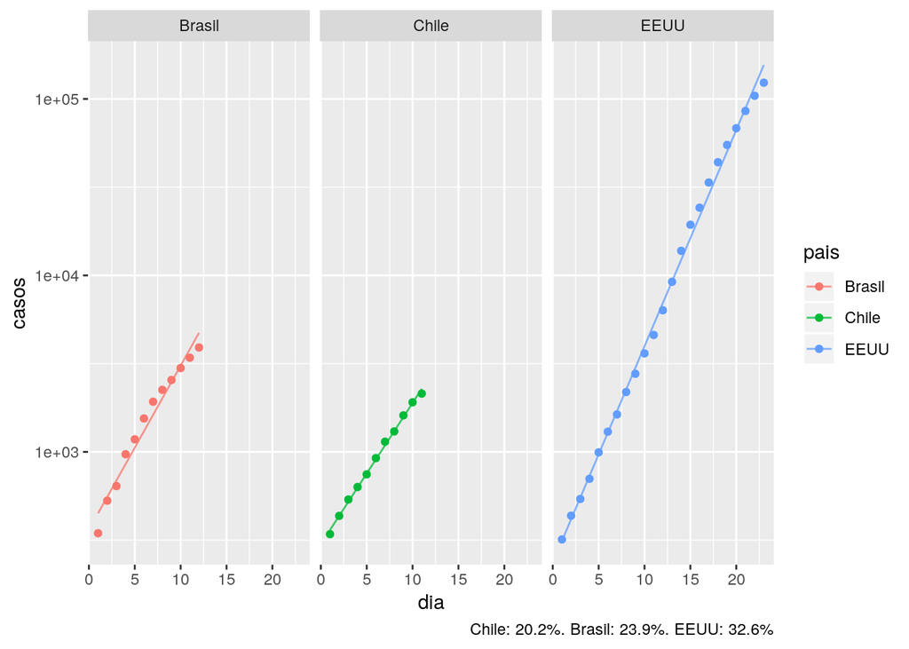

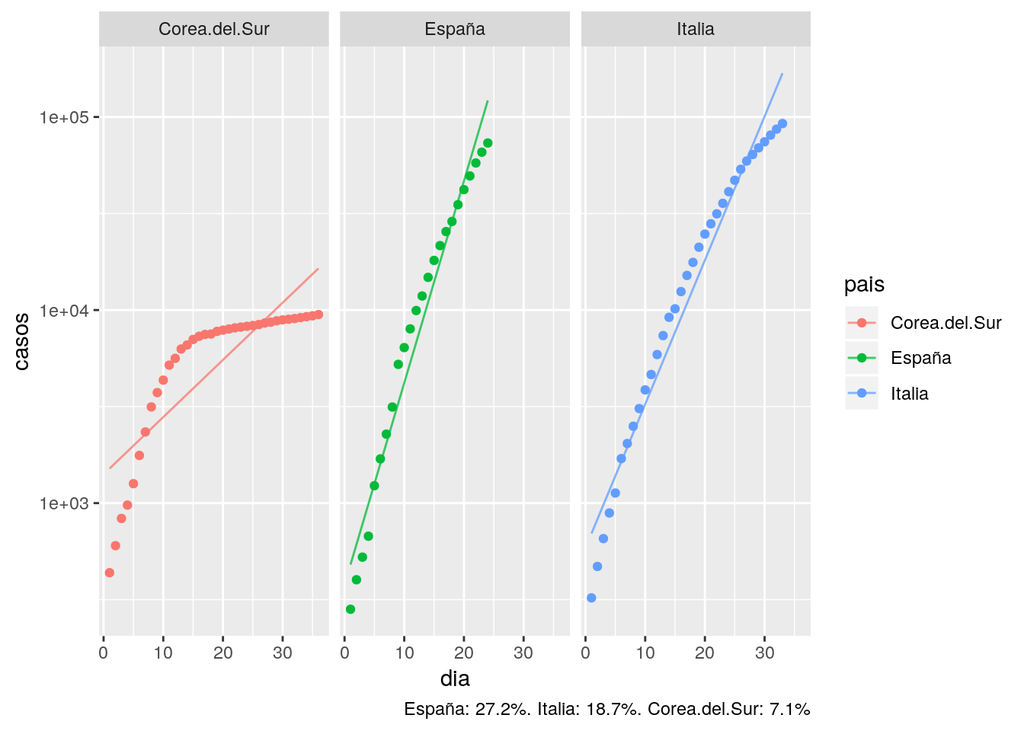

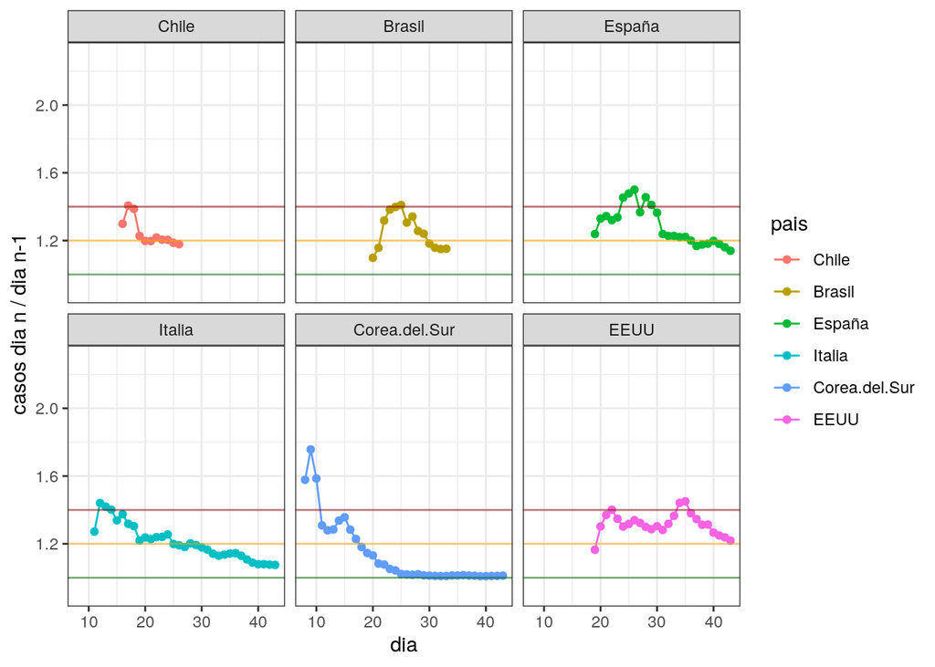

## Predicción

**NOTA**: Se presentan aquí tres metodologías de predicción. Recuerden que corresponden a un ejercicio para mostrar las bondades y dificultades de cada técnica

Para predecir, se ocupan tres técnicas distintas:

- regresión exponencial sobre datos totales: se ajusta la serie a la expresión $y=a * r^t$ usando regresión lineal. Es válida si el proceso no cambia a lo largo del tiempo, por lo que el periodo estudiado debe seleccionarse con cuidado. Se caracteriza porque el intervalo de confianza es constante al transformar los datos a logaritmo.
- tendencia sobre casos nuevos + AR(1): Se modela la tendencia de los casos nuevos usando regresión exponencial, con regresión cuadrada, más la relación que existe entre dos mediciones contiguas. El error estándar aumenta a lo largo del tiempo, tanto por el error al calcular la tendencia, como por el componente AR(1). El valor medio obtenido es bastante sensible a los cambios en las mediciones finales.
- ARIMA(1,1,0) más deriva: Se ocupa un modelo autorregresivo, con diferenciación y deriva. Esto implica que se asume que los datos tienen una tendencia constante (como el modelo de regresión exponencial), pero se modela la relación que existe entre casos contiguos (como el modelo de tendencia). Tiende a generar modelos menos variables que el de tendencia + AR(1), pero asume que la curva de crecimiento es la misma de toda la serie de datos.

## Predicción Chile y Brasil

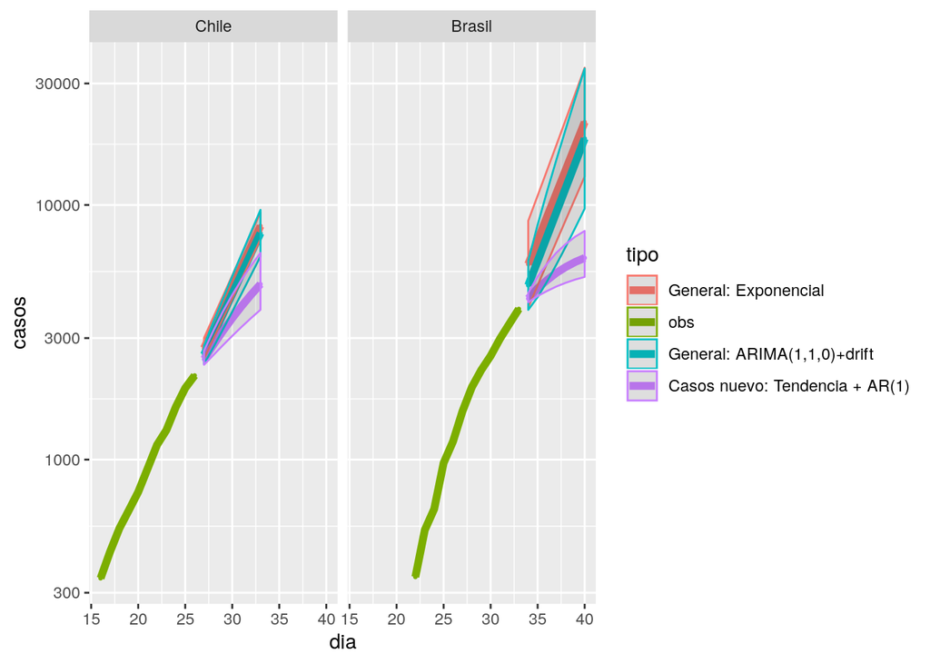

Tendencia + AR(1) : Chile

|  | dia | casos | li | ls |
| --- | --- | --- | --- | --- |
| **12** | 27 | 2480 | 2358 | 2672 |
| **13** | 28 | 2823 | 2574 | 3214 |
| **14** | 29 | 3198 | 2810 | 3808 |
| **15** | 30 | 3593 | 3060 | 4435 |
| **16** | 31 | 4009 | 3323 | 5094 |
| **17** | 32 | 4441 | 3595 | 5779 |
| **18** | 33 | 4886 | 3876 | 6484 |

Tendencia + AR(1) : Brasil

|  | dia | casos | li | ls |
| --- | --- | --- | --- | --- |
| **13** | 34 | 4288 | 4147 | 4512 |
| **14** | 35 | 4708 | 4390 | 5237 |
| **15** | 36 | 5068 | 4593 | 5875 |
| **16** | 37 | 5414 | 4785 | 6497 |
| **17** | 38 | 5710 | 4949 | 7032 |
| **18** | 39 | 5974 | 5095 | 7509 |
| **19** | 40 | 6194 | 5216 | 7907 |

Exponencial : Chile

|  | dia | casos | li | ls |
| --- | --- | --- | --- | --- |
| **12** | 27 | 2738 | 2493 | 3006 |
| **13** | 28 | 3291 | 2986 | 3628 |
| **14** | 29 | 3957 | 3575 | 4380 |
| **15** | 30 | 4758 | 4279 | 5290 |
| **16** | 31 | 5720 | 5119 | 6391 |
| **17** | 32 | 6877 | 6123 | 7724 |
| **18** | 33 | 8268 | 7321 | 9337 |

Exponencial : Brasil

|  | dia | casos | li | ls |
| --- | --- | --- | --- | --- |
| **13** | 34 | 5855 | 3957 | 8662 |
| **14** | 35 | 7253 | 4836 | 10878 |
| **15** | 36 | 8984 | 5900 | 13679 |
| **16** | 37 | 11128 | 7190 | 17224 |
| **17** | 38 | 13785 | 8752 | 21711 |
| **18** | 39 | 17075 | 10643 | 27394 |
| **19** | 40 | 21151 | 12931 | 34597 |

ARIMA(1,1,0) con deriva : Chile

|  | dia | casos | li | ls |
| --- | --- | --- | --- | --- |
| **12** | 27 | 2580 | 2374 | 2804 |
| **13** | 28 | 3098 | 2763 | 3474 |
| **14** | 29 | 3722 | 3239 | 4278 |
| **15** | 30 | 4472 | 3811 | 5247 |
| **16** | 31 | 5372 | 4495 | 6420 |
| **17** | 32 | 6453 | 5311 | 7841 |
| **18** | 33 | 7752 | 6282 | 9566 |

ARIMA(1,1,0) con deriva : Brasil

|  | dia | casos | li | ls |
| --- | --- | --- | --- | --- |
| **13** | 34 | 4834 | 3873 | 6035 |
| **14** | 35 | 6028 | 4345 | 8363 |
| **15** | 36 | 7520 | 5004 | 11303 |
| **16** | 37 | 9383 | 5840 | 15076 |
| **17** | 38 | 11707 | 6872 | 19942 |
| **18** | 39 | 14606 | 8135 | 26226 |
| **19** | 40 | 18224 | 9671 | 34340 |

## Predicción España e Italia

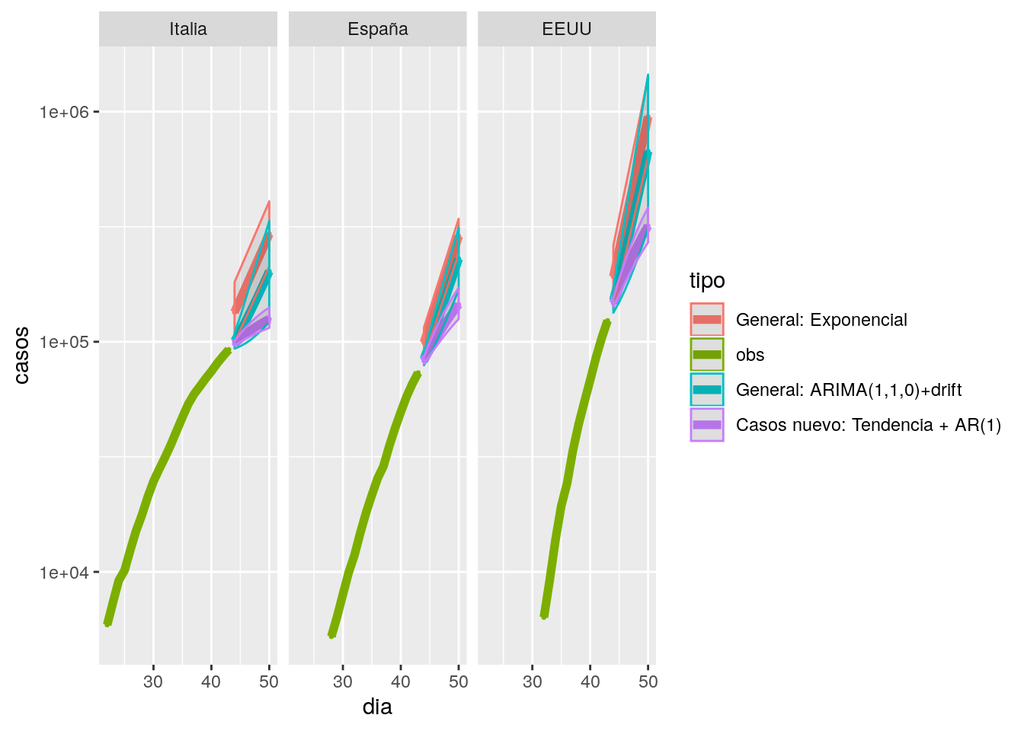

Tendencia + AR(1) : Italia

|  | dia | casos | li | ls |
| --- | --- | --- | --- | --- |
| **23** | 44 | 97988 | 96229 | 100569 |
| **24** | 45 | 103308 | 99851 | 108385 |
| **25** | 46 | 108371 | 103297 | 115823 |
| **26** | 47 | 113142 | 106544 | 122833 |
| **27** | 48 | 117594 | 109575 | 129374 |
| **28** | 49 | 121708 | 112375 | 135417 |
| **29** | 50 | 125470 | 114936 | 140945 |

Tendencia + AR(1) : España

|  | dia | casos | li | ls |
| --- | --- | --- | --- | --- |
| **17** | 44 | 82598 | 80092 | 86033 |
| **18** | 45 | 92313 | 87180 | 99350 |
| **19** | 46 | 102443 | 94569 | 113234 |
| **20** | 47 | 112891 | 102192 | 127556 |
| **21** | 48 | 123558 | 109974 | 142177 |
| **22** | 49 | 134335 | 117836 | 156949 |
| **23** | 50 | 145110 | 125697 | 171718 |

Tendencia + AR(1) : EEUU

|  | dia | casos | li | ls |
| --- | --- | --- | --- | --- |
| **13** | 44 | 147104 | 141659 | 154188 |
| **14** | 45 | 171877 | 160267 | 187169 |
| **15** | 46 | 198951 | 180522 | 223358 |
| **16** | 47 | 227441 | 201821 | 261468 |
| **17** | 48 | 257248 | 224102 | 301343 |
| **18** | 49 | 287831 | 246962 | 342257 |
| **19** | 50 | 318784 | 270098 | 383667 |

Exponencial : Italia

|  | dia | casos | li | ls |
| --- | --- | --- | --- | --- |
| **23** | 44 | 134311 | 99255 | 181747 |
| **24** | 45 | 153063 | 112728 | 207831 |
| **25** | 46 | 174434 | 127999 | 237716 |
| **26** | 47 | 198789 | 145304 | 271961 |
| **27** | 48 | 226544 | 164912 | 311210 |
| **28** | 49 | 258175 | 187126 | 356200 |
| **29** | 50 | 294222 | 212288 | 407778 |

Exponencial : España

|  | dia | casos | li | ls |
| --- | --- | --- | --- | --- |
| **17** | 44 | 99029 | 85092 | 115250 |
| **18** | 45 | 118297 | 101331 | 138103 |
| **19** | 46 | 141313 | 120636 | 165533 |
| **20** | 47 | 168807 | 143583 | 198462 |
| **21** | 48 | 201650 | 170853 | 237999 |
| **22** | 49 | 240884 | 203257 | 285476 |
| **23** | 50 | 287751 | 241756 | 342495 |

Exponencial : EEUU

|  | dia | casos | li | ls |
| --- | --- | --- | --- | --- |
| **13** | 44 | 191794 | 139910 | 262920 |
| **14** | 45 | 250430 | 180684 | 347099 |
| **15** | 46 | 326992 | 233076 | 458750 |
| **16** | 47 | 426960 | 300354 | 606934 |
| **17** | 48 | 557490 | 386700 | 803711 |
| **18** | 49 | 727927 | 497469 | 1065146 |
| **19** | 50 | 950469 | 639509 | 1412633 |

ARIMA(1,1,0) con deriva : Italia

|  | dia | casos | li | ls |
| --- | --- | --- | --- | --- |
| **23** | 44 | 100735 | 93362 | 108690 |
| **24** | 45 | 111234 | 95615 | 129404 |
| **25** | 46 | 124034 | 98763 | 155772 |
| **26** | 47 | 139285 | 102937 | 188468 |
| **27** | 48 | 157209 | 108199 | 228419 |
| **28** | 49 | 178091 | 114588 | 276786 |
| **29** | 50 | 202280 | 122151 | 334972 |

ARIMA(1,1,0) con deriva : España

|  | dia | casos | li | ls |
| --- | --- | --- | --- | --- |
| **17** | 44 | 84289 | 79035 | 89893 |
| **18** | 45 | 98442 | 87509 | 110742 |
| **19** | 46 | 115946 | 98229 | 136857 |
| **20** | 47 | 137174 | 111356 | 168979 |
| **21** | 48 | 162677 | 127129 | 208165 |
| **22** | 49 | 193166 | 145879 | 255782 |
| **23** | 50 | 229524 | 168029 | 313526 |

ARIMA(1,1,0) con deriva : EEUU

|  | dia | casos | li | ls |
| --- | --- | --- | --- | --- |
| **13** | 44 | 151345 | 133691 | 171331 |
| **14** | 45 | 189370 | 148548 | 241411 |
| **15** | 46 | 240446 | 167660 | 344831 |
| **16** | 47 | 308367 | 192166 | 494833 |
| **17** | 48 | 398183 | 223297 | 710039 |
| **18** | 49 | 516564 | 262541 | 1016368 |
| **19** | 50 | 672276 | 311752 | 1449727 |

## Predicción Corea del Sur

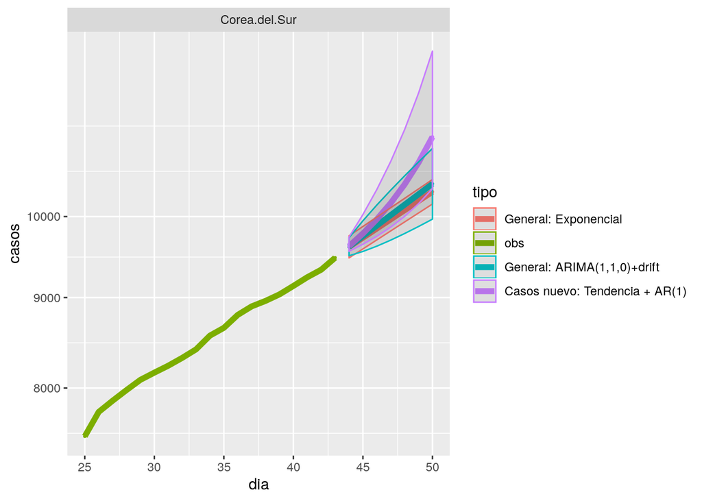

Tendencia + AR(1) : Corea.del.Sur

|  | dia | casos | li | ls |
| --- | --- | --- | --- | --- |
| **20** | 44 | 9622 | 9558 | 9737 |
| **21** | 45 | 9782 | 9646 | 10027 |
| **22** | 46 | 9965 | 9747 | 10358 |
| **23** | 47 | 10177 | 9864 | 10744 |
| **24** | 48 | 10428 | 10003 | 11199 |
| **25** | 49 | 10728 | 10168 | 11743 |
| **26** | 50 | 11092 | 10369 | 12403 |

Exponencial : Corea.del.Sur

|  | dia | casos | li | ls |
| --- | --- | --- | --- | --- |
| **20** | 44 | 9613 | 9476 | 9753 |
| **21** | 45 | 9729 | 9588 | 9872 |
| **22** | 46 | 9846 | 9701 | 9993 |
| **23** | 47 | 9964 | 9815 | 10116 |
| **24** | 48 | 10084 | 9930 | 10240 |
| **25** | 49 | 10205 | 10047 | 10366 |
| **26** | 50 | 10328 | 10165 | 10494 |

ARIMA(1,1,0) con deriva : Corea.del.Sur

|  | dia | casos | li | ls |
| --- | --- | --- | --- | --- |
| **20** | 44 | 9615 | 9503 | 9728 |
| **21** | 45 | 9749 | 9556 | 9946 |
| **22** | 46 | 9883 | 9622 | 10151 |
| **23** | 47 | 10019 | 9698 | 10350 |
| **24** | 48 | 10156 | 9782 | 10544 |
| **25** | 49 | 10295 | 9872 | 10736 |
| **26** | 50 | 10436 | 9966 | 10927 |

Fuentes de información:

- Chile: https://www.minsal.cl/nuevo-coronavirus-2019-ncov/casos-confirmados-en-chile-covid-19/.
- Otros países: https://www.worldometers.info/coronavirus/#countries